# si544-day6-more-basic-regression

Tabassum Nisha

10/4/2019

```r
library(tidyverse)
library(moderndive)
library(skimr)
```

```r
library(gapminder)
library(ggplot2)
```

## One categorical predictor variable

Let’s return to the Gapminder data:

```r
library(gapminder)
gapminder2007 <- gapminder %>%
  filter(year == 2007) %>%
  select(country, lifeExp, continent, gdpPercap)
```

### Learning Check 544.6.1

What did the above code block do?

It filtered the data of different countries in different continents in 2007 namely, life expectency and gdp per captia.

Let’s take a glimpse of the data:

```r
glimpse(gapminder2007)
```

```
## Observations: 142
## Variables: 4
## $ country   <fct> Afghanistan, Albania, Algeria, Angola, Argentina, Aust…
## $ lifeExp   <dbl> 43.828, 76.423, 72.301, 42.731, 75.320, 81.235, 79.829…
## $ continent <fct> Asia, Europe, Africa, Africa, Americas, Oceania, Europ…
## $ gdpPercap <dbl> 974.5803, 5937.0295, 6223.3675, 4797.2313, 12779.3796,…
```

### Learning Check 544.6.2

Use skim() to get a “feel” for lifeExp and continent (Hint: look at last week’s notebook for a refresher of how to use “skim()”. What does the output tell you?

```r
gapminder2007 %>% select(lifeExp, continent) %>% skim()
```

```
## Skim summary statistics
##  n obs: 142
##  n variables: 2
##
## ── Variable type:factor ────────────────────────────────────────────────────────────────
##   variable missing complete   n n_unique
##  continent       0      142 142        5
##                          top_counts ordered
##  Afr: 52, Asi: 33, Eur: 30, Ame: 25   FALSE
##
## ── Variable type:numeric ───────────────────────────────────────────────────────────────
##  variable missing complete   n  mean    sd    p0   p25   p50   p75 p100
##   lifeExp       0      142 142 67.01 12.07 39.61 57.16 71.94 76.41 82.6
##      hist
##  ▂▂▂▂▂▃▇▇
```

```r
gapminder2007$lifeExp
```

[output not shown]

Let’s take a look at the distribution of worldwide life expectancies:

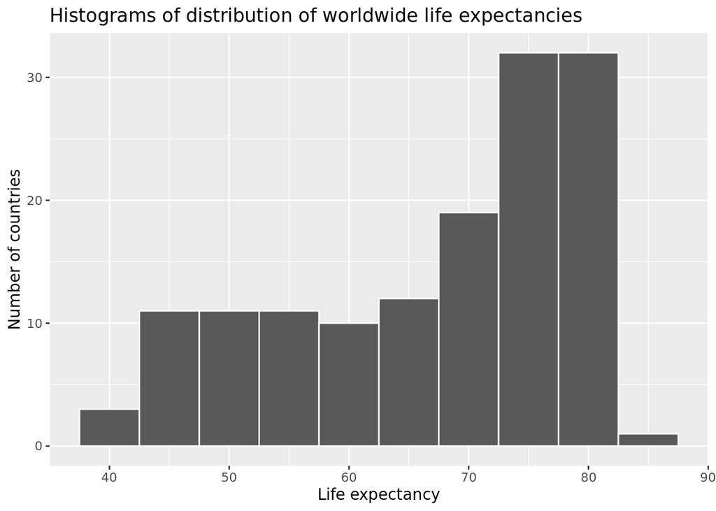

```r
ggplot(gapminder2007, aes(x = lifeExp)) +
  geom_histogram(binwidth = 5, color = "white") +
  labs(x = "Life expectancy", y = "Number of countries",
       title = "Histograms of distribution of worldwide life expectancies")
```

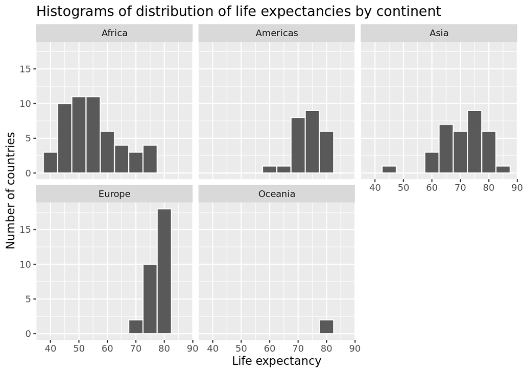

```r
ggplot(gapminder2007, aes(x = lifeExp)) +
  geom_histogram(binwidth = 5, color = "white") +
  labs(x = "Life expectancy", y = "Number of countries",
       title = "Histograms of distribution of life expectancies by continent") +
  facet_wrap(~ continent, nrow = 2)
```

And now let’s look at the same data with a boxplot:

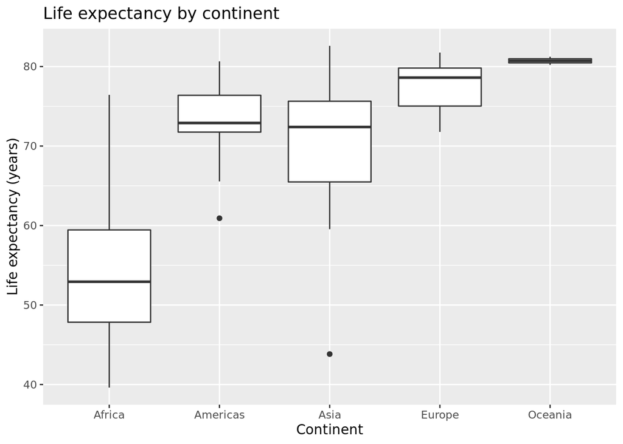

```r
ggplot(gapminder2007, aes(x = continent, y = lifeExp)) +
  geom_boxplot() +
  labs(x = "Continent", y = "Life expectancy (years)",
       title = "Life expectancy by continent")
```

```r
lifeExp_by_continent <- gapminder2007 %>%
  group_by(continent) %>%
  summarize(median = median(lifeExp), mean = mean(lifeExp))
lifeExp_by_continent
```

```
## # A tibble: 5 x 3
##   continent median  mean
##   <fct>      <dbl> <dbl>
## 1 Africa      52.9  54.8
## 2 Americas    72.9  73.6
## 3 Asia        72.4  70.7
## 4 Europe      78.6  77.6
## 5 Oceania     80.7  80.7
```

### Learning Check 544.6.3

Add a column called “deltaAfrica” to the lifeExp_by_continent dataframe that is calculated as the difference of each mean value from the mean value for Africa. Round your values to 1 decimal point. For example, the value for “Americas” should be 18.8.

```r
lifeExp_by_continent$mean
```

```
## [1] 54.80604 73.60812 70.72848 77.64860 80.71950
```

```r
lifeExp_by_continent$mean[1]
```

```
## [1] 54.80604
```

```r
lifeExp_by_continent %>% mutate(deltaAfrica = mean - mean[1])
```

```
## # A tibble: 5 x 4
##   continent median  mean deltaAfrica
##   <fct>      <dbl> <dbl>       <dbl>
## 1 Africa      52.9  54.8         0
## 2 Americas    72.9  73.6        18.8
## 3 Asia        72.4  70.7        15.9
## 4 Europe      78.6  77.6        22.8
## 5 Oceania     80.7  80.7        25.9
```

```r
lifeExp_by_continent %>% mutate(deltaAfrica = round(mean - mean[1],1))
```

```
## # A tibble: 5 x 4
##   continent median  mean deltaAfrica
##   <fct>      <dbl> <dbl>       <dbl>
## 1 Africa      52.9  54.8         0
## 2 Americas    72.9  73.6        18.8
## 3 Asia        72.4  70.7        15.9
## 4 Europe      78.6  77.6        22.8
## 5 Oceania     80.7  80.7        25.9
```

Let’s fit a regression model to our categorical explanatory variable:

```r
# Fit regression model:
lifeExp_model <- lm(lifeExp ~ continent, data = gapminder2007)
# Get regression table:
get_regression_table(lifeExp_model)
```

```
## # A tibble: 5 x 7
##   term              estimate std_error statistic p_value lower_ci upper_ci
##   <chr>                <dbl>     <dbl>     <dbl>   <dbl>    <dbl>    <dbl>
## 1 intercept             54.8      1.02     53.4        0     52.8     56.8
## 2 continentAmericas     18.8      1.8      10.4        0     15.2     22.4
## 3 continentAsia         15.9      1.65      9.68       0     12.7     19.2
## 4 continentEurope       22.8      1.70     13.5        0     19.5     26.2
## 5 continentOceania      25.9      5.33      4.86       0     15.4     36.4
```

### Learning Check 544.6.4

How do the values of “estimate” compare to “deltaAfrica” from the earlier Learning Check?

They are extactly the same. The baseline value is decided alphabetically. Here baseline value is Africa.

```r
get_regression_summaries(lifeExp_model)
```

```
## # A tibble: 1 x 8
##   r_squared adj_r_squared   mse  rmse sigma statistic p_value    df
##       <dbl>         <dbl> <dbl> <dbl> <dbl>     <dbl>   <dbl> <dbl>
## 1     0.635         0.625  52.8  7.26  7.40      59.7       0     5
```

### Learning Check 544.6.5

How “good” is this model?

p value = 0 hence pretty good model.

### Learning Check 544.6.6

```r
get_regression_points(lifeExp_model, ID='country') %>% filter(continent == 'Asia') %>% select(c('country','residual')) %>% arrange(residual)
```

```
## # A tibble: 33 x 2
##    country     residual
##    <fct>          <dbl>
##  1 Afghanistan   -26.9
##  2 Iraq          -11.2
##  3 Cambodia      -11.0
##  4 Myanmar        -8.66
##  5 Yemen, Rep.    -8.03
##  6 Nepal          -6.94
##  7 Bangladesh     -6.67
##  8 India          -6.03
##  9 Pakistan       -5.24
## 10 Mongolia       -3.92
## # … with 23 more rows
```